# Moderation Skills Lab

01 04 2022

## Learning Goals

- Running and interpreting moderation analyses in R
  - Centring predictors
  - Creating interaction terms
  - Running the model
  - Simple slope analysis
  - Plotting the moderation

## What was a moderation again?

- When does X predicts Y?
- The relationship of X and Y is conditional of M
- Does the relationship between alcohol consume and relationship problems depend on the impulsiveness of one person?

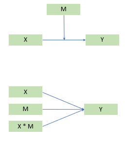

## Centering predictors

- Centering facilitates interpretation
- b parameters represent the regression when the other predictor is zero
- 0 does not always represent a meaningful score
- Grand mean centering = Subtract mean score from each participant

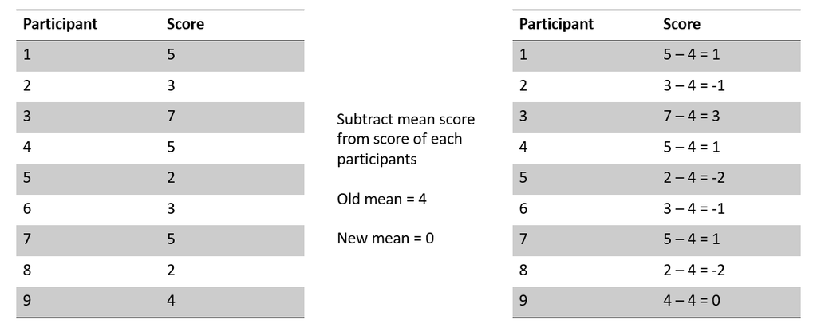

- b then represents the relationship at the mean of the moderator

## How to center?

- Method 1:

  dplyr::mutate

```r
data <- data%>%
  dplyr::mutate(
    var1_c = var1 - mean(var1, na.rm = T),
    var2_c = var2 - mean(var2, na.rm = T)
  )
```

- A function is a convenient way to center multiple variables simultanously

```r
centre <- function(var){
  var - mean(var, na.rm = T)
}

data <- data%>%
  dplyr::mutate(
    dplyr::across(c(var1, var2), list(cent = centre))
  )
```

## How to center?

- Method 2:

  dplyr::mutate & misty::center

```r
data <- data%>%
  dplyr::mutate(
    misty::center(var1),
    misty::center(var2))

data <- data%>%
  dplyr::mutate(
    misty::center(var1, value = 0),
    misty::center(var2, value = 0))

# you can choose any value
```

## Running the model

- Model: y = a + b + a*b
- Model: relationship problems = alcohol consume + impulsiveness + alcohol consume*impulsiveness
- Creating the interaction term: Not necessary, but good to know

```r
data <- data %>%
  dplyr::mutate(
    interaction = var1_cent*var2_cent
    )
#make sure to use the centered predictors
```

## Running the model

- Method 1

  lm

```r
model.a <- lm(DV ~ var1_cent + var2_cent + var1_cent:var2_cent,
              data = data)
```

- Method 2

```r
model.b <- lm(DV ~ var1_cent*var2_cent, data = data)
```

- Method 3

```r
model.c <- lm(DV ~ var1_cent + var2_cent + interaction, data = data) # if interaction is created by hand
```

## How to examine the results?

- Method 1

  summary

```r
summary(model.a)
```

- Method 2

  broom::glance & broom::tidy

```r
broom::glance(model.b)
broom::tidy(model.b, conf.int = T)%>%
  dplyr::mutate(
    dplyr::across(where(is.numeric), ~round(.,3))
  )
```

- Method 3

  parameters::model_parameters

```r
parameters::model_parameters(model.c, robust = T, vcov.type = "HC4", digits = 3)
```

## How to probe your interaction?

- Always follow up a signficant interaction to understand what is actually going on
  - Simple Slopes = at what level of our moderator the relationship is significant
  - Johnson-Neyman Interval = in which ’zone’is the relationship significant
- Method 1

  interactions::sim_slopes

```r
interactions::sim_slopes(
  model.b,
  pred = var1_cent,
  modx = var2_cent,
  jnplot = T,
  robust = T,
  confint = T
)
```

- Method 2

```r
reghelper::simple_slopes(
  model.b)
```

## How to plot moderation?

- Method 1

  interactions::interact_plot

```r
interactions::interact_plot(
  model.1b,
  pred = var1_cent,
  modx = var2_cent,
  interval = T,
  x.label = "predictor",
  y.label = "criteria",
  legend.main = "moderator"
)
```

- Method 2

  sjPlot::plot_model

```r
sjPlot::plot_model(
  model.1b,
  type = "int",
  mdrt.values = "meansd",
  axis.title = c("predictor", "criteria"),
  title = "title",
  legend.title = "moderator"
  )
```

## Example 2: Categorical moderator

Important: Categorical predictors do not need to be centered, rest is the same

```r
# Run and inspect the model
model.2 <- lm(rel_prob ~ alc_cent*gender, data = data)
summary(model.2)

# Examine the simple effect
interactions::sim_slopes(
  model.2,
  pred = alc_cent,
  modx = gender,
  jnplot = T,  robust = T,  confint = T
)

# Plot the model
interactions::interact_plot(
  model.2,
  pred = alc_cent,
  modx = gender,  interval = T,
  x.label = "Alcohol consumption (in ml)",
  y.label = "Predicted relationship problems",
  legend.main = "Gender"
)
```

## That is it for today!

Any questions get in touch: R.Kesberg@sussex.ac.uk